# Youtube Project

Jasmine Brown

11/4/2019

Introduction

Go to the app store on your phone and try to find an app to watch videos. YouTube comes up. YouTube is the most popular app and website to watch any video you would like to see. YouTube is an American video-sharing website headquartered in San Bruno, California. Three people Chad Hurley, Steve Chen, and Jawed Karim, created the service in February 2005. Google bought the site in November 2006 for US$1.65 billion; YouTube now operates as one of Google’s affiliates. The app allows you to explore new content, music, news, and more with the official app or the website. They also allow you to subscribe to channels with your favorite content, share with friends, or upload your videos for everyone to see. YouTube’s most popular videos are trending. Trending helps viewers see what’s happening on YouTube and in the world. Trending aims to surface videos that a wide range of viewers would find interesting. Some trends are predictable, like a new song from a famous artist or a new movie trailer. Others are surprising, like a viral video. Trending is not personalized and displays the same list of trending videos in each country to all users. The list of trending videos is updated roughly every 15 minutes. With each update, videos may move up, down, or stay in the same position in the list. YouTube maintains a list of the top trending videos. YouTube uses a combination of factors, including measuring several views, shares, comments, and likes to make the commercials and determine trending videos. This dataset is a daily record of the top trending YouTube videos and the factors that influences them. Analyzing this dataset, we can look at the main factors that include making the videos trending, such as likes, dislikes, and comments. We can view what is needed to make a video be on the trending list. To analyze this data plan is to use linear regression with the variables likes, dislikes, comments, trending data, and publish time and names. We aim to help YouTube to provide users with a threshold so they can know precisely know what is expected for views, likes, dislikes, and comments for their video to be considered as a trending video.

Questions

Can the number of views from a trending video be predicted by the likes, dislikes, comment count?

What are the characteristics of a trending video?

The variables used are

trending_date - the date they were trending

title - the titles of the videos

publish_time - the times the videos were published

views - the number of views

likes - The number of likes

dislikes - The number of dislikes

comment_count - The number of comments

The necessary libraries needed for the project have been installed and are loaded here. The dplyr packages work for selecting variables. The rmarkdown package makes the rmarkdown file nit and run. The Ggplot2 package makes all plots run and work.

```r
library(tidyr) #The swiss knife!
library(dplyr)
```

```r
library(rmarkdown)
library(ggplot2)
library(caret)
```

```r
getwd()
```

```
## [1] "/Users/jasminebrown/Desktop/youtube"
```

```r
Mydata <- read.csv("USvideos.csv")
data <- read.csv("data.csv")
```

This function deletes the extra variable

```r
data <- select(data, -c(X.1))
```

Data Wrangling

The data set was provided in a nearly cleaned manner. However, multiple data wrangling techniques were performed on the data frame to transom it into a document that can be analyzed. These techniques include removing unnecessary variables, changing the names of some columns, adding variables, and including functions for calculation.

This function comes with the tidyr package to select the variables that I would like to use.

```r
data <- Mydata[ , c("trending_date","title","publish_time","views", "likes", "dislikes","comment_count")]
```

This allows us to see the names of the variables. I decided not to change any.

```r
names(data)
```

```
## [1] "trending_date" "title"         "publish_time"  "views"
## [5] "likes"         "dislikes"      "comment_count"
```

```r
glimpse(data)
```

```
## Observations: 200
## Variables: 7
## $ trending_date <fct> 17.13.11, 17.13.11, 17.13.11, 17.13.11, 17.13.11, …
## $ title         <fct> "The Trump Presidency: Last Week Tonight with John…
## $ publish_time  <fct> 2017-11-13T07:30:00.000Z, 2017-11-12T19:05:24.000Z…
## $ views         <int> 993345, 2568721, 118585, 1867990, 669608, 1926875,…
## $ likes         <int> 65551, 132724, 6183, 123933, 21357, 15159, 4158, 5…
## $ dislikes      <int> 3544, 4495, 361, 1836, 591, 2288, 321, 291, 156, 1…
## $ comment_count <int> 8128, 7494, 1374, 16635, 3050, 1837, 2882, 251, 10…
```

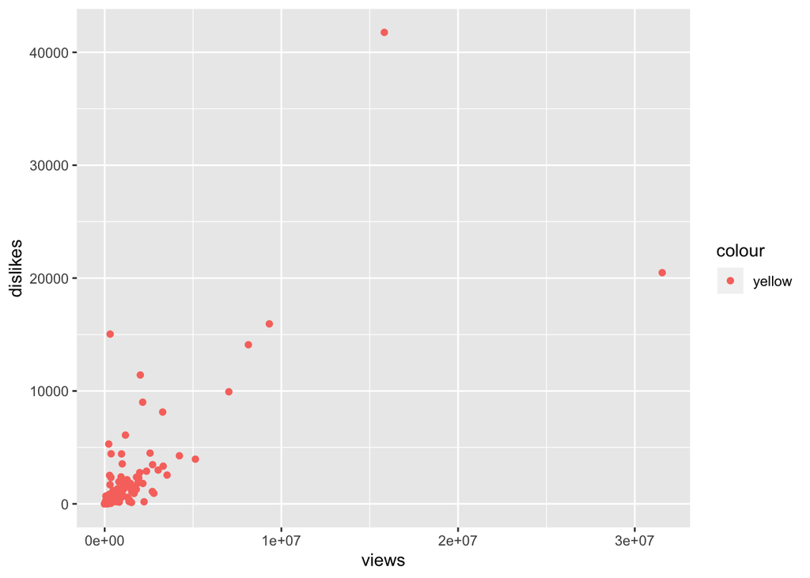

```r
ggplot(data, aes(x = views, y = dislikes, color="yellow")) + geom_point()
```

The graph shows the titles aren’t significant.

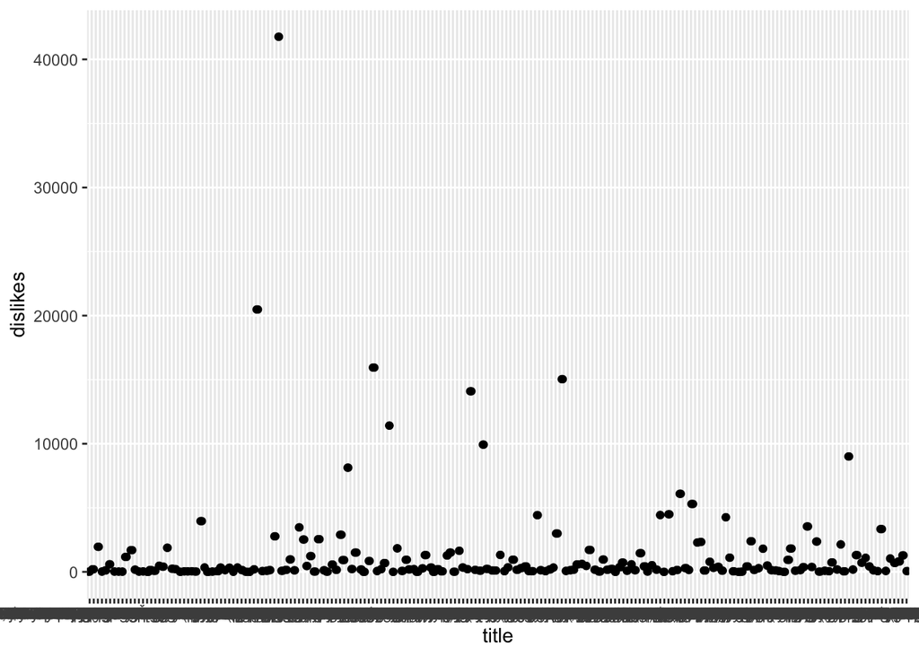

```r
ggplot(data, aes(x = title, y = dislikes)) +
  geom_point() + geom_jitter()
```

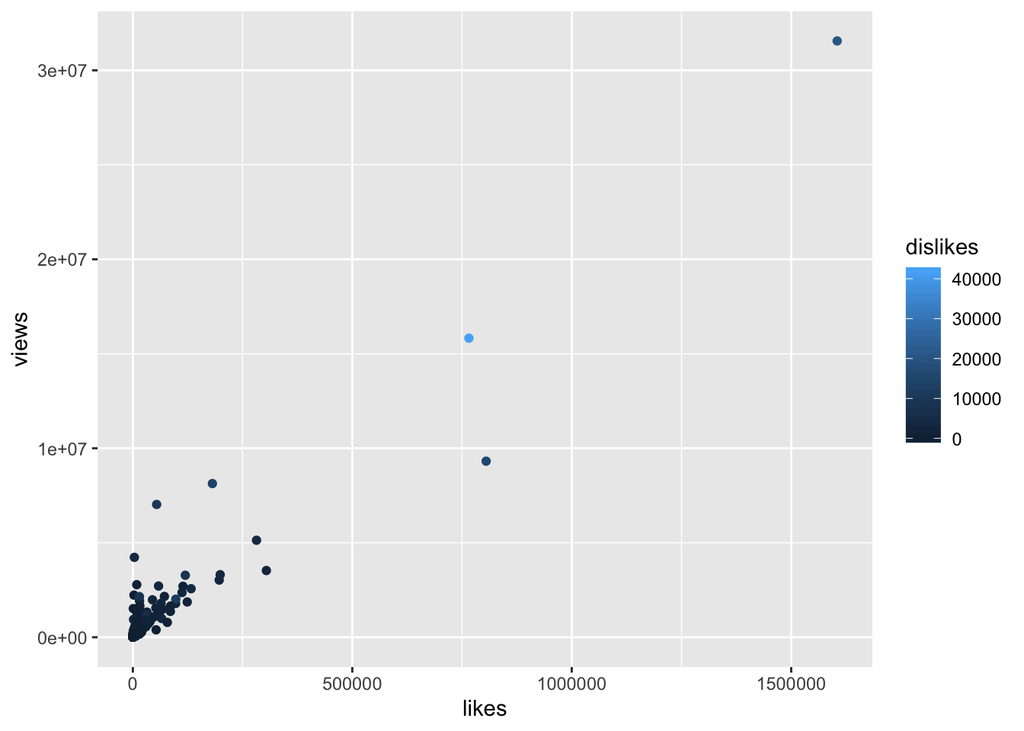

```r
ggplot(data, aes(y = views, x = likes, color=dislikes)) + geom_point()
```

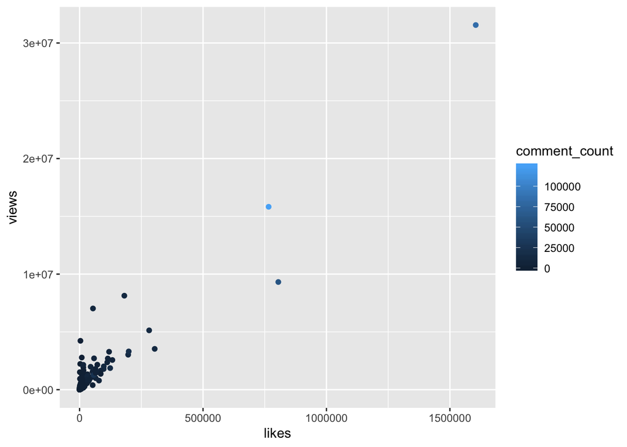

```r
ggplot(data, aes(y = views, x = likes, color=comment_count)) + geom_point()
```

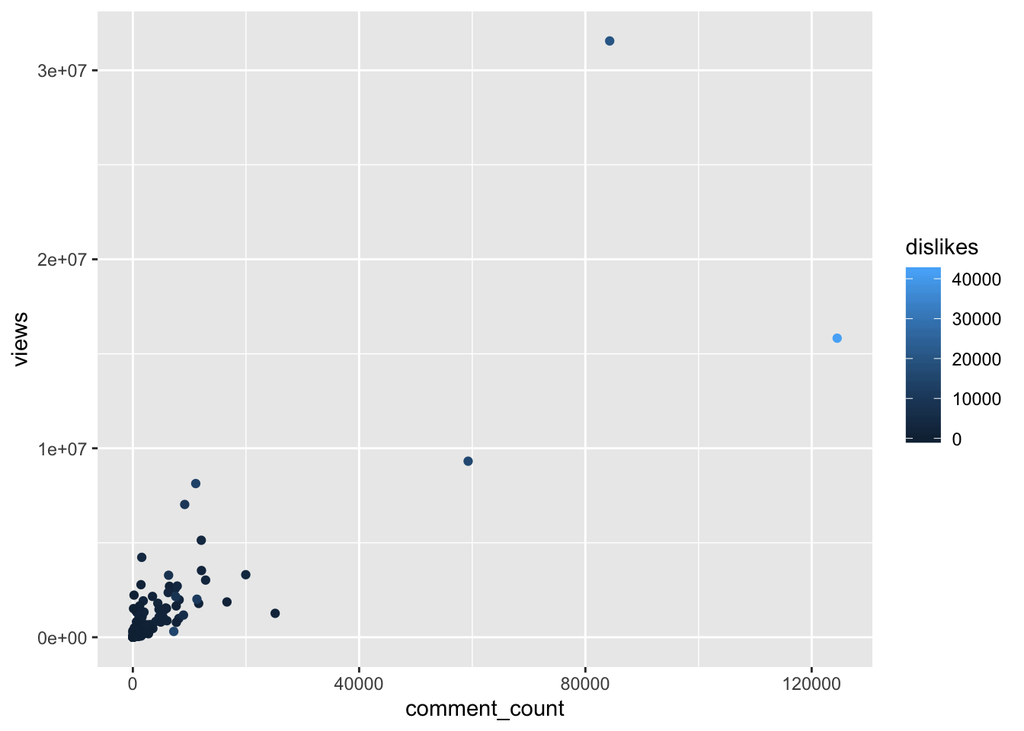

```r
ggplot(data, aes(y = views, x = comment_count, color=dislikes)) + geom_point()
```

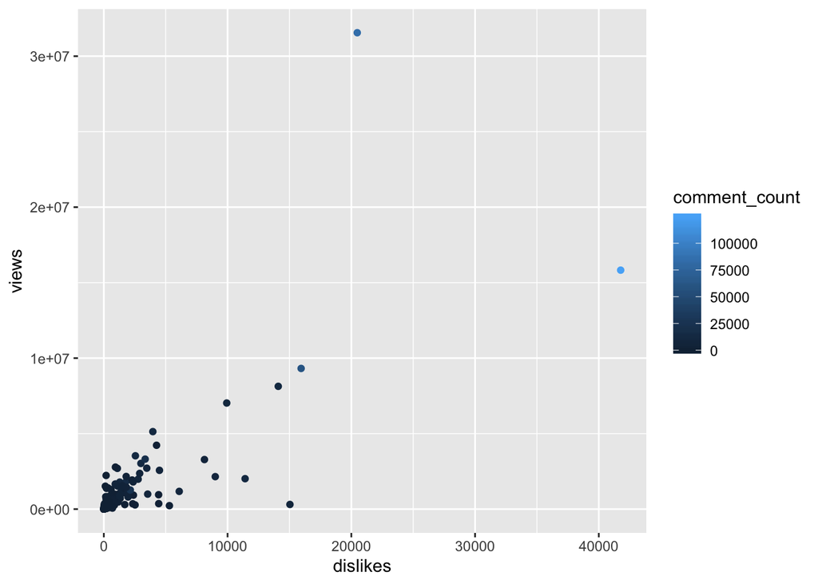

```r
ggplot(data, aes(y = views, x = dislikes, color=comment_count)) + geom_point()
```

```r
data  %>%
  group_by(comment_count) %>%
  summarise(n_comments = n(),
            mean_dislikes = mean(dislikes),
            std_error = sd(dislikes) / sqrt(n_comments))
```

```
## # A tibble: 190 x 4
##    comment_count n_comments mean_dislikes std_error
##            <int>      <int>         <dbl>     <dbl>
##  1             0          7         132.      120.
##  2             1          2           0.5       0.5
##  3             2          2           0         0
##  4            10          1           5        NA
##  5            11          1           2        NA
##  6            17          2          56.5      22.5
##  7            18          1           2        NA
##  8            19          1           6        NA
##  9            22          1          23        NA
## 10            30          1          50        NA
## # … with 180 more rows
```

Machine Learning The plots created, and we have a clearer understanding of the data. The models below explore the relationship between the dependent variables and the independent variables. After creating multiple models, we conclude that the model of best fit has a dependent variable is views, and the independent variables are likes, dislikes, and comments. Since the dependent variable is a numerical value, multiple linear regression will be used as the machine learning technique. For the machine learning portion of the capstone project, the number of views is predicted, given the number of likes, dislikes, and comments.

```r
set.seed(7)
validation_index <- createDataPartition(data$views, p=0.80, list=FALSE)
testing <- data[-validation_index,]
# use the remaining 80% of data to training and testing the models
training <- data[validation_index,]
```

## Model1

In model1, the dependent variable views, and the dependent variable is disliked. The independent variable is statistically significant, but $R^2$ is only 0.6216. We can produce a better model.

```r
model1 <- lm(views ~ dislikes, likes , data = training)
summary(model1)
```

```
##
## Call:
## lm(formula = views ~ dislikes, data = training, subset = likes)
##
## Residuals:
##     Min      1Q  Median      3Q     Max
## -916612 -100861  -34129  396267  590524
##
## Coefficients:
##             Estimate Std. Error t value Pr(>|t|)
## (Intercept)  71777.4   199924.4   0.359   0.7289
## dislikes       444.7      111.9   3.973   0.0041 **
## ---
## Signif. codes:  0 '***' 0.001 '**' 0.01 '*' 0.05 '.' 0.1 ' ' 1
##
## Residual standard error: 498400 on 8 degrees of freedom
##   (149 observations deleted due to missingness)
## Multiple R-squared:  0.6637, Adjusted R-squared:  0.6216
## F-statistic: 15.78 on 1 and 8 DF,  p-value: 0.004102
```

## Model2

```r
model2 <- lm(views ~ comment_count, likes , data = training)
summary(model2)
```

```
##
## Call:
## lm(formula = views ~ comment_count, data = training, subset = likes)
##
## Residuals:
##     Min      1Q  Median      3Q     Max
## -654848  -79934     -67   81227  660839
##
## Coefficients:
##                Estimate Std. Error t value Pr(>|t|)
## (Intercept)    30513.10  151320.57   0.202  0.84523
## comment_count    325.46      56.62   5.748  0.00043 ***
## ---
## Signif. codes:  0 '***' 0.001 '**' 0.01 '*' 0.05 '.' 0.1 ' ' 1
##
## Residual standard error: 379500 on 8 degrees of freedom
##   (149 observations deleted due to missingness)
## Multiple R-squared:  0.8051, Adjusted R-squared:  0.7807
## F-statistic: 33.04 on 1 and 8 DF,  p-value: 0.00043
```

## Model3

In model3, the dependent variable views, and the independent variables are dislikes and comments. The independent variables are statistically significant, but $R^2$ is only 0.755. We can produce a better model.

```r
model3 <- lm(views ~ dislikes + comment_count , data = training)
summary(model3)
```

```
##
## Call:
## lm(formula = views ~ dislikes + comment_count, data = training)
##
## Residuals:
##      Min       1Q   Median       3Q      Max
## -3910645  -308934  -227326    69529  3916867
##
## Coefficients:
##                Estimate Std. Error t value Pr(>|t|)
## (Intercept)   325753.51   69265.70   4.703 5.58e-06 ***
## dislikes         232.10      33.94   6.839 1.68e-10 ***
## comment_count     55.60      13.02   4.270 3.37e-05 ***
## ---
## Signif. codes:  0 '***' 0.001 '**' 0.01 '*' 0.05 '.' 0.1 ' ' 1
##
## Residual standard error: 827800 on 157 degrees of freedom
## Multiple R-squared:  0.758,  Adjusted R-squared:  0.755
## F-statistic: 245.9 on 2 and 157 DF,  p-value: < 2.2e-16
```

## Model4

In model4, the dependent variable views, and the independent variables are likes, dislikes, and comment_count. The independent variables are statistically significant, but $R^2$ is only $0.8383$. This is the best model for all possible combinations of more than one independent variable from the choice of, likes, dislikes, and comment count.

```r
model4 <- lm(views ~ dislikes + comment_count + likes, data = training)
summary(model4)
```

```
##
## Call:
## lm(formula = views ~ dislikes + comment_count + likes, data = training)
##
## Residuals:
##      Min       1Q   Median       3Q      Max
## -3128790  -199845  -147366    82714  4176630
##
## Coefficients:
##                 Estimate Std. Error t value Pr(>|t|)
## (Intercept)   204729.204  57837.194   3.540 0.000528 ***
## dislikes         218.804     27.611   7.925 4.07e-13 ***
## comment_count    -39.937     14.943  -2.673 0.008329 **
## likes             15.468      1.709   9.050 5.46e-16 ***
## ---
## Signif. codes:  0 '***' 0.001 '**' 0.01 '*' 0.05 '.' 0.1 ' ' 1
##
## Residual standard error: 672500 on 156 degrees of freedom
## Multiple R-squared:  0.8413, Adjusted R-squared:  0.8383
## F-statistic: 275.7 on 3 and 156 DF,  p-value: < 2.2e-16
```